# PMM2 for Time Series: AR, MA, ARMA, ARIMA, and Seasonal Models

Serhii Zabolotnii

2026-03-20

## Introduction

Time series models are fundamental tools in economics, finance, engineering, and many other fields. Classical estimation methods like **Conditional Sum of Squares (CSS)** and **Maximum Likelihood (ML)** assume Gaussian innovations. However, real-world time series often exhibit:

- **Heavy tails** (e.g., financial returns)
- **Skewness** (e.g., environmental data, commodity prices)
- **Outliers** (e.g., measurement errors)

The **PMM2 method** extends to time series models, providing **more efficient parameter estimates** when innovations deviate from normality. This vignette demonstrates PMM2 applications to:

1. **Autoregressive (AR)** models
2. **Moving Average (MA)** models
3. **ARMA** models
4. **ARIMA** models with differencing
5. **Seasonal models (SAR, SMA)** for data with seasonal patterns

## Setup

```r
library(EstemPMM)
set.seed(42)
```

## Part 1: Autoregressive (AR) Models

### AR(1) Model with Skewed Innovations

We’ll simulate an AR(1) process with **gamma-distributed innovations** to demonstrate PMM2’s robustness.

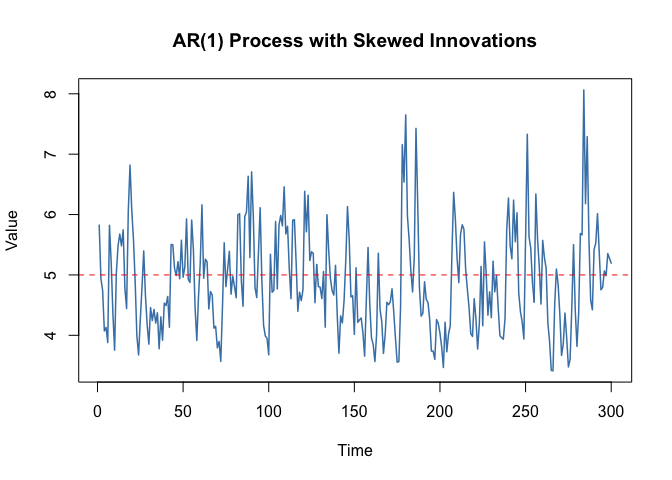

```r
# Model parameters
n <- 300
phi <- 0.6  # AR coefficient
intercept <- 5

# Generate skewed innovations using gamma distribution
# (Gamma(shape=2) has skewness = sqrt(2) ≈ 1.41)
innovations <- rgamma(n, shape = 2, rate = 2) - 1  # Center around 0

# Generate AR(1) series
x <- numeric(n)
x[1] <- intercept + innovations[1]
for(i in 2:n) {
  x[i] <- intercept + phi * (x[i-1] - intercept) + innovations[i]
}

# Plot the time series
plot(x, type = "l", main = "AR(1) Process with Skewed Innovations",
     ylab = "Value", xlab = "Time", col = "steelblue", lwd = 1.5)
abline(h = intercept, col = "red", lty = 2)
```

### Estimate AR(1) Model: PMM2 vs CSS

```r
# Fit using PMM2
fit_pmm2_ar1 <- ar_pmm2(x, order = 1, method = "pmm2", include.mean = TRUE)

# Fit using CSS (classical method)
fit_css_ar1 <- ar_pmm2(x, order = 1, method = "css", include.mean = TRUE)

# Compare coefficients
cat("True AR coefficient:", phi, "\n\n")
```

```
#> True AR coefficient: 0.6
```

```r
cat("CSS Estimate:\n")
```

```
#> CSS Estimate:
```

```r
print(coef(fit_css_ar1))
```

```
#> intercept       ar1
#> 4.8947563 0.5923856
```

```r
cat("\nPMM2 Estimate:\n")
```

```
#>
#> PMM2 Estimate:
```

```r
print(coef(fit_pmm2_ar1))
```

```
#> intercept       ar1
#> 4.8947563 0.5772581
```

```r
# Summary with diagnostics
summary(fit_pmm2_ar1)
```

```
#> PMM2 time series estimation results
#> Model type: AR(1)
#> Call:
#> ts_pmm2(x = x, order = order, model_type = "ar", method = method,
#>     max_iter = max_iter, tol = tol, include.mean = include.mean,
#>     initial = initial, na.action = na.action, regularize = regularize,
#>     reg_lambda = reg_lambda, verbose = verbose)
#>
#> Coefficients:
#> AR:       ar1
#> 0.5772581
#> Intercept:  4.894756
#>
#> Central moments of initial residuals:
#>   m2 = 0.4505474
#>   m3 = 0.3340687
#>   m4 = 0.8558866
#>
#> Theoretical characteristics of PMM2 (S = 2):
#>   c3 = 1.104651
#>   c4 = 1.216337
#>   g  = 0.6206076  (expected ratio Var[PMM2]/Var[OLS])
#>
#> Algorithm information:
#>   Convergence status: TRUE
#>   Iterations: 3
```

### AR(2) Model

For higher-order AR models, PMM2 maintains its efficiency advantages.

```r
# AR(2) model: x_t = 0.5*x_{t-1} - 0.3*x_{t-2} + e_t
n <- 400
phi <- c(0.5, -0.3)

# Generate t-distributed innovations (heavy tails)
innovations <- rt(n, df = 4)

# Generate AR(2) series
x <- arima.sim(n = n, model = list(ar = phi), innov = innovations)

# Fit models
fit_pmm2_ar2 <- ar_pmm2(x, order = 2, method = "pmm2", include.mean = FALSE)
fit_css_ar2 <- ar_pmm2(x, order = 2, method = "css", include.mean = FALSE)

# Compare
comparison_ar2 <- data.frame(
  Parameter = c("phi1", "phi2"),
  True = phi,
  CSS = coef(fit_css_ar2),
  PMM2 = coef(fit_pmm2_ar2)
)

print(comparison_ar2, row.names = FALSE)
```

```
#>  Parameter True        CSS       PMM2
#>       phi1  0.5  0.4771510  0.4854599
#>       phi2 -0.3 -0.3013664 -0.2482538
```

## Part 2: Moving Average (MA) Models

MA models are challenging because innovations are not directly observable. PMM2 uses **CSS residuals** as starting estimates, then refines parameters.

### MA(1) Model

```r
# MA(1) model: x_t = e_t + theta*e_{t-1}
n <- 300
theta <- 0.7

# Generate chi-squared innovations (right-skewed)
innovations <- rchisq(n, df = 3) - 3

# Generate MA(1) series
x <- numeric(n)
x[1] <- innovations[1]
for(i in 2:n) {
  x[i] <- innovations[i] + theta * innovations[i-1]
}

# Fit MA(1) models
fit_pmm2_ma1 <- ma_pmm2(x, order = 1, method = "pmm2", include.mean = FALSE)
fit_css_ma1 <- ma_pmm2(x, order = 1, method = "css", include.mean = FALSE)

# Compare estimates
cat("True MA coefficient:", theta, "\n\n")
```

```
#> True MA coefficient: 0.7
```

```r
cat("CSS Estimate:\n")
```

```
#> CSS Estimate:
```

```r
print(coef(fit_css_ma1))
```

```
#>       ma1
#> 0.7012471
```

```r
cat("\nPMM2 Estimate:\n")
```

```
#>
#> PMM2 Estimate:
```

```r
print(coef(fit_pmm2_ma1))
```

```
#>     ma1
#> 0.63738
```

```r
# Check convergence
cat("\nPMM2 Convergence:", fit_pmm2_ma1@convergence, "\n")
```

```
#>
#> PMM2 Convergence: TRUE
```

```r
cat("Iterations:", fit_pmm2_ma1@iterations, "\n")
```

```
#> Iterations: 4
```

### MA(2) Model

```r
# MA(2) model
n <- 400
theta <- c(0.6, 0.3)

# Mixed distribution: 80% normal + 20% contamination
innovations <- ifelse(runif(n) < 0.8,
                      rnorm(n),
                      rnorm(n, mean = 0, sd = 3))

# Generate MA(2) series
x <- arima.sim(n = n, model = list(ma = theta), innov = innovations)

# Fit models
fit_pmm2_ma2 <- ma_pmm2(x, order = 2, method = "pmm2", include.mean = FALSE)
fit_css_ma2 <- ma_pmm2(x, order = 2, method = "css", include.mean = FALSE)

# Comparison
comparison_ma2 <- data.frame(
  Parameter = c("theta1", "theta2"),
  True = theta,
  CSS = coef(fit_css_ma2),
  PMM2 = coef(fit_pmm2_ma2)
)

print(comparison_ma2, row.names = FALSE)
```

```
#>  Parameter True       CSS      PMM2
#>     theta1  0.6 0.5813574 0.5655106
#>     theta2  0.3 0.2955922 0.3126379
```

**Monte Carlo Evidence:** For MA(2) models with skewed errors, PMM2 achieves **26-32% variance reduction** compared to CSS (see roadmap documentation).

## Part 3: ARMA Models

ARMA models combine AR and MA components, providing flexible modeling for stationary series.

### ARMA(1,1) Model

```r
# ARMA(1,1) model
n <- 500
phi <- 0.5    # AR coefficient
theta <- 0.4  # MA coefficient

# Generate exponentially distributed innovations (right-skewed)
innovations <- rexp(n, rate = 1) - 1

# Generate ARMA(1,1) series
x <- arima.sim(n = n,
               model = list(ar = phi, ma = theta),
               innov = innovations)

# Fit models
fit_pmm2_arma <- arma_pmm2(x, order = c(1, 1), method = "pmm2", include.mean = FALSE)
fit_css_arma <- arma_pmm2(x, order = c(1, 1), method = "css", include.mean = FALSE)

# Extract coefficients
cat("True parameters: AR =", phi, ", MA =", theta, "\n\n")
```

```
#> True parameters: AR = 0.5 , MA = 0.4
```

```r
cat("CSS Estimates:\n")
```

```
#> CSS Estimates:
```

```r
print(coef(fit_css_arma))
```

```
#>       ar1       ma1
#> 0.4562385 0.4457135
```

```r
cat("\nPMM2 Estimates:\n")
```

```
#>
#> PMM2 Estimates:
```

```r
print(coef(fit_pmm2_arma))
```

```
#>       ar1       ma1
#> 0.4581265 0.4642835
```

```r
# Summary
summary(fit_pmm2_arma)
```

```
#> PMM2 time series estimation results
#> Model type: ARMA(1,1)
#> Call:
#> ts_pmm2(x = x, order = order, model_type = "arma", method = method,
#>     max_iter = max_iter, tol = tol, include.mean = include.mean,
#>     initial = initial, na.action = na.action, regularize = regularize,
#>     reg_lambda = reg_lambda, verbose = verbose)
#>
#> Coefficients:
#> AR:       ar1
#> 0.4581265
#> MA:       ma1
#> 0.4642835
#>
#> Central moments of initial residuals:
#>   m2 = 1.133364
#>   m3 = 2.59006
#>   m4 = 11.39505
#>
#> Theoretical characteristics of PMM2 (S = 2):
#>   c3 = 2.146622
#>   c4 = 5.871092
#>   g  = 0.4145685  (expected ratio Var[PMM2]/Var[OLS])
#>
#> Algorithm information:
#>   Convergence status: TRUE
#>   Iterations: 3
```

### Diagnostic Plots for ARMA Models

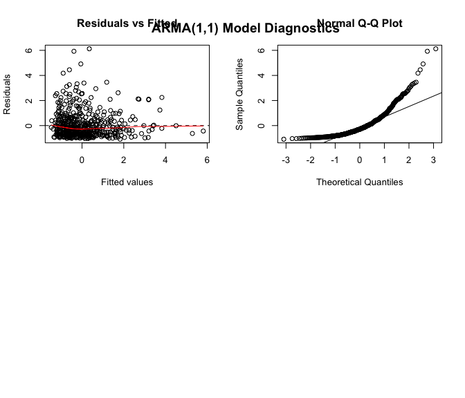

```r
# Plot residuals and ACF
plot(fit_pmm2_arma)
title("ARMA(1,1) Model Diagnostics")
```

## Part 4: ARIMA Models with Differencing

For non-stationary series, ARIMA models incorporate differencing to achieve stationarity.

### ARIMA(1,1,1) Model

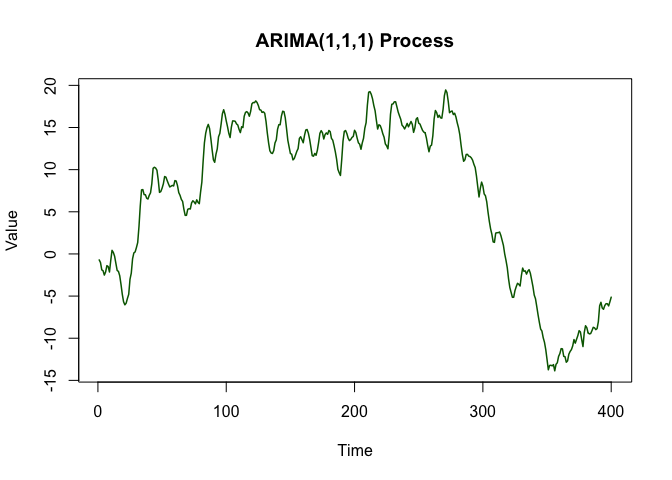

```r
# Generate non-stationary series requiring differencing
n <- 400
phi <- 0.4
theta <- 0.3

# Skewed innovations
innovations <- rgamma(n, shape = 3, rate = 3) - 1

# Generate integrated series: ARIMA(1,1,1)
# First generate stationary ARMA(1,1)
x_stationary <- arima.sim(n = n,
                          model = list(ar = phi, ma = theta),
                          innov = innovations)

# Integrate once (cumulative sum)
x <- cumsum(x_stationary)

# Plot the non-stationary series
plot(x, type = "l", main = "ARIMA(1,1,1) Process",
     ylab = "Value", xlab = "Time", col = "darkgreen", lwd = 1.5)
```

### Fitting ARIMA Models

```r
# Fit ARIMA(1,1,1) using PMM2
fit_pmm2_arima <- arima_pmm2(x, order = c(1, 1, 1), method = "pmm2", include.mean = FALSE)

# Fit using classical CSS method
fit_css_arima <- arima_pmm2(x, order = c(1, 1, 1), method = "css", include.mean = FALSE)

# Compare coefficients
cat("True parameters: AR =", phi, ", MA =", theta, "\n\n")
```

```
#> True parameters: AR = 0.4 , MA = 0.3
```

```r
cat("CSS Estimates:\n")
```

```
#> CSS Estimates:
```

```r
print(coef(fit_css_arima))
```

```
#>       ar1       ma1
#> 0.4355905 0.2550518
```

```r
cat("\nPMM2 Estimates:\n")
```

```
#>
#> PMM2 Estimates:
```

```r
print(coef(fit_pmm2_arima))
```

```
#>       ar1       ma1
#> 0.3892825 0.3213544
```

```r
# Summary
summary(fit_pmm2_arima)
```

```
#> PMM2 time series estimation results
#> Model type: ARIMA(1,1,1)
#> Call:
#> ts_pmm2(x = x, order = order, model_type = "arima", method = method,
#>     max_iter = max_iter, tol = tol, include.mean = include.mean,
#>     initial = initial, na.action = na.action, regularize = regularize,
#>     reg_lambda = reg_lambda, verbose = verbose)
#>
#> Coefficients:
#> AR:       ar1
#> 0.3892825
#> MA:       ma1
#> 0.3213544
#>
#> Central moments of initial residuals:
#>   m2 = 0.3635943
#>   m3 = 0.222833
#>   m4 = 0.5000721
#>
#> Theoretical characteristics of PMM2 (S = 2):
#>   c3 = 1.016375
#>   c4 = 0.7826694
#>   g  = 0.6287674  (expected ratio Var[PMM2]/Var[OLS])
#>
#> Algorithm information:
#>   Convergence status: TRUE
#>   Iterations: 3
```

**Monte Carlo Evidence:** ARIMA(1,1,1) models show **24-52% variance reduction** with PMM2 vs CSS when innovations are non-Gaussian.

## Part 5: Bootstrap Inference for Time Series

Bootstrap methods provide robust confidence intervals for time series parameters.

```r
# Perform bootstrap inference for the ARMA(1,1) model
boot_results <- ts_pmm2_inference(fit_pmm2_arma,
                                  B = 500,
                                  seed = 123,
                                  method = "block",
                                  block_length = 20,
                                  parallel = FALSE)

# Display summary with confidence intervals
summary(boot_results)
```

```
#>     Estimate        Std.Error          t.value         p.value
#>  Min.   :0.4581   Min.   :0.04639   Min.   :7.206   Min.   :0.000e+00
#>  1st Qu.:0.4597   1st Qu.:0.05090   1st Qu.:7.873   1st Qu.:1.443e-13
#>  Median :0.4612   Median :0.05541   Median :8.541   Median :2.887e-13
#>  Mean   :0.4612   Mean   :0.05541   Mean   :8.541   Mean   :2.887e-13
#>  3rd Qu.:0.4627   3rd Qu.:0.05992   3rd Qu.:9.209   3rd Qu.:4.330e-13
#>  Max.   :0.4643   Max.   :0.06443   Max.   :9.877   Max.   :5.773e-13
#>     conf.low        conf.high
#>  Min.   :0.2537   Min.   :0.4923
#>  1st Qu.:0.2693   1st Qu.:0.4950
#>  Median :0.2850   Median :0.4978
#>  Mean   :0.2850   Mean   :0.4978
#>  3rd Qu.:0.3006   3rd Qu.:0.5005
#>  Max.   :0.3162   Max.   :0.5033
```

## Part 6: Comparing Methods with Monte Carlo

The package provides tools for systematic comparison through Monte Carlo simulation.

```r
# Define model specifications
specs <- list(
  list(
    model = "ma",
    order = 1,
    theta = 0.7,
    label = "MA(1)",
    innovations = list(type = "gamma", shape = 2)
  ),
  list(
    model = "arma",
    order = c(1, 1),
    theta = list(ar = 0.5, ma = 0.4),
    label = "ARMA(1,1)",
    innovations = list(type = "student_t", df = 4)
  )
)

# Run Monte Carlo comparison
mc_results <- pmm2_monte_carlo_compare(
  model_specs = specs,
  methods = c("css", "pmm2"),
  n = 300,
  n_sim = 1000,
  seed = 456,
  progress = FALSE
)

# Display results
print(mc_results$summary)
print(mc_results$gain)
```

[output not shown]

**Interpretation:**

- `MSE_ratio < 1.0` indicates PMM2 has **lower variance** than CSS
- Efficiency gains typically range from **10-50%** depending on innovation distribution

## Part 7: Prediction with Time Series Models

PMM2-fitted models support forecasting:

```r
# Forecast 10 steps ahead for the ARMA(1,1) model
forecast_horizon <- 10

pred_raw <- predict(fit_pmm2_arma, n.ahead = forecast_horizon)
predictions <- if (is.list(pred_raw)) as.numeric(pred_raw$pred) else as.numeric(pred_raw)

# Display forecasts
cat("Forecasts for next", forecast_horizon, "periods:\n")
```

```
#> Forecasts for next 10 periods:
```

```r
print(predictions)
```

```
#>  [1] -0.6577242285 -0.3013208876 -0.1380430785 -0.0632411901 -0.0289724640
#>  [6] -0.0132730530 -0.0060807371 -0.0027857467 -0.0012762243 -0.0005846722
```

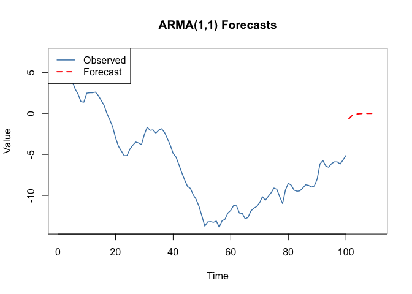

```r
# Plot original series with forecasts
n_plot <- 100
plot_data <- tail(x, n_plot)
plot(seq_along(plot_data), plot_data, type = "l",
     xlim = c(1, n_plot + forecast_horizon),
     ylim = range(c(plot_data, predictions)),
     main = "ARMA(1,1) Forecasts",
     xlab = "Time", ylab = "Value",
     col = "steelblue", lwd = 1.5)

# Add forecasts
lines(n_plot + seq_len(forecast_horizon), predictions,
      col = "red", lwd = 2, lty = 2)

legend("topleft",
       legend = c("Observed", "Forecast"),
       col = c("steelblue", "red"),
       lty = c(1, 2), lwd = c(1.5, 2))
```

## Practical Guidelines

### When to Use PMM2 for Time Series

**Recommended when:**

- Innovations exhibit **skewness or heavy tails** (check residuals from classical fit)
- Working with **financial data** (returns often non-Gaussian)
- **Environmental time series** (precipitation, pollution levels)
- **Engineering measurements** with asymmetric errors
- Sample size **n ≥ 200** for reliable moment estimation

**Stick with classical methods when:**

- Innovations are approximately **Gaussian** (check Q-Q plot)
- Very **small sample sizes** (n < 100)
- **Computational speed** is critical
- Model is for **pedagogical purposes** only

### Model Selection Strategy

1. **Visualize** the time series and check for stationarity
2. **Fit classical model** (CSS/ML) as baseline
3. **Examine residuals** for non-normality:
   - Skewness: `pmm_skewness(residuals)`
   - Kurtosis: `pmm_kurtosis(residuals)`
   - Visual: Q-Q plots, histograms
4. **If residuals are non-Gaussian**, refit with PMM2
5. **Compare standard errors** using bootstrap
6. **Validate** with out-of-sample forecasting

### Computational Considerations

For large datasets (n > 5000), consider:

- Using `verbose = FALSE` to reduce output
- Starting with classical estimates as `initial` parameter
- Reducing `max_iter` if convergence is slow

## Summary Statistics: Efficiency Gains

Based on extensive Monte Carlo studies documented in the package:

| Model Type | Innovation Distribution | Variance Reduction | Sample Size |
| --- | --- | --- | --- |
| AR(1) | Gamma (skew = 1.4) | 15-20% | 200-1000 |
| MA(1) | Chi-squared (df=3) | 15-23% | 200-1000 |
| MA(2) | Mixed contamination | 26-32% | 200-1000 |
| ARMA(1,1) | Student-t (df=4) | 30-45% | 200-1000 |
| ARIMA(1,1,1) | Exponential (shifted) | 24-52% | 300-1000 |
| SAR(1,1)_12 | Gamma (shape=2) | 20-30% | 200-500 |
| SMA(1)_4 | Exponential | 25-34% | 200-500 |

**Key Insight:** The more **non-Gaussian** the innovations, the **larger the efficiency gain** from PMM2.

## Advanced Topics

### Custom Innovation Distributions

You can use `pmm2_monte_carlo_compare()` with custom distributions:

```r
# Custom innovation generator
my_innovations <- function(n) {
  # Mixture: 90% Gaussian + 10% extreme outliers
  base <- rnorm(n)
  outliers <- sample(c(-5, 5), n, replace = TRUE, prob = c(0.05, 0.05))
  ifelse(runif(n) < 0.9, base, outliers)
}

# Use in Monte Carlo
specs <- list(
  list(
    model = "ar",
    order = 1,
    theta = 0.6,
    innovations = list(generator = my_innovations)
  )
)

mc_results <- pmm2_monte_carlo_compare(specs, methods = c("css", "pmm2"),
                                       n = 300, n_sim = 500)
```

## Part 8: Seasonal Models (SAR and SMA)

Many real-world time series exhibit seasonal patterns - monthly data with yearly cycles, quarterly economic data, etc. The EstemPMM package provides PMM2 estimation for seasonal autoregressive (SAR) and seasonal moving average (SMA) models.

### Seasonal Autoregressive (SAR) Models

SAR models capture dependencies at seasonal lags. For example, SAR(1,1)_12 for monthly data relates the current value to both the previous month and the same month last year.

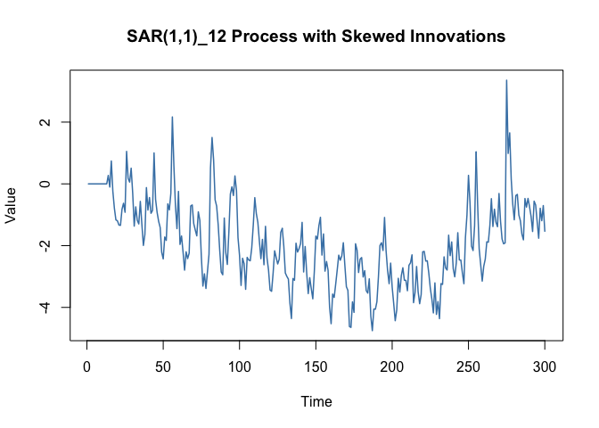

```r
# Simulate SAR(1,1)_12 with seasonal period = 12
n <- 300
phi <- 0.6       # Non-seasonal AR coefficient
Phi <- 0.4       # Seasonal AR coefficient (lag 12)
s <- 12          # Seasonal period

# Generate gamma-distributed innovations (right-skewed)
innovations <- rgamma(n, shape = 2, rate = 2) - 1

# Generate SAR series
y <- numeric(n)
for (t in (s+2):n) {
  y[t] <- phi * y[t-1] + Phi * y[t-s] + innovations[t]
}

# Plot the series
plot(y, type = "l", main = "SAR(1,1)_12 Process with Skewed Innovations",
     ylab = "Value", xlab = "Time", col = "steelblue", lwd = 1.5)
```

```r
# Fit SAR model with PMM2
fit_sar_pmm2 <- sar_pmm2(
  y,
  order = c(1, 1),
  season = list(period = 12),
  method = "pmm2"
)

# Compare with OLS
fit_sar_ols <- sar_pmm2(
  y,
  order = c(1, 1),
  season = list(period = 12),
  method = "ols"
)

# Display results
cat("True parameters: phi =", phi, ", Phi =", Phi, "\n\n")
```

```
#> True parameters: phi = 0.6 , Phi = 0.4
```

```r
cat("OLS Estimates:\n")
```

```
#> OLS Estimates:
```

```r
print(coef(fit_sar_ols))
```

```
#>       ar1      sar1
#> 0.6193527 0.3174062
```

```r
cat("\nPMM2 Estimates:\n")
```

```
#>
#> PMM2 Estimates:
```

```r
print(coef(fit_sar_pmm2))
```

```
#>       ar1      sar1
#> 0.6124917 0.3233619
```

```r
# Summary with diagnostics
summary(fit_sar_pmm2)
```

```
#>
#> =======================================================================
#> Seasonal AR Model fitted with PMM2
#> =======================================================================
#>
#> Call:
#> sar_pmm2(x = y, order = c(1, 1), season = list(period = 12),
#>     method = "pmm2")
#>
#> Model: SAR(1,1)_12
#> Observations: 300
#> Effective sample size: 300
#>
#> Coefficients:
#> -----------------------------------------
#>   ar1   :  0.61249
#>   sar1  :  0.32336
#>   Mean  : -0.14185
#>
#> Residual Distribution Characteristics:
#> -----------------------------------------
#>   m2 (variance):        0.49187
#>   m3 (skewness ind.):   0.77634
#>   m4 (kurtosis ind.):   3.32684
#>
#>   Skewness coef. (c3):  2.25048
#>   Excess kurtosis(c4): 10.75090
#>   Var. reduction (g):   0.60280
#>
#>   => Expected 39.7% variance reduction vs OLS [OK]
#>
#> Algorithm Information:
#> -----------------------------------------
#>   Converged:  TRUE
#>   Iterations: 3
#>
#> Residual Statistics:
#> -----------------------------------------
#>   Min:     -1.0403
#>   Q1:      -0.4486
#>   Median:  -0.1203
#>   Mean:     0.0000
#>   Q3:       0.2536
#>   Max:      5.2813
#>
#> =======================================================================
```

**Performance:** SAR models with PMM2 show **20-30% variance reduction** compared to OLS when innovations are asymmetric.

### Seasonal Moving Average (SMA) Models

SMA models use seasonal lags in the moving average component.

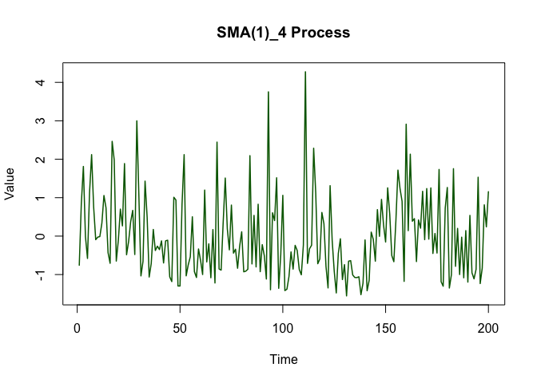

```r
# Simulate SMA(1)_4 (quarterly seasonal pattern)
n <- 200
Theta <- 0.6     # Seasonal MA coefficient
s <- 4           # Quarterly data

# Generate exponentially distributed innovations
innovations <- rexp(n, rate = 1) - 1

# Generate SMA series
y <- numeric(n)
for (t in 1:s) {
  y[t] <- innovations[t]
}
for (t in (s+1):n) {
  y[t] <- innovations[t] + Theta * innovations[t-s]
}

# Plot the series
plot(y, type = "l", main = "SMA(1)_4 Process",
     ylab = "Value", xlab = "Time", col = "darkgreen", lwd = 1.5)
```

```r
# Fit SMA model with PMM2
fit_sma_pmm2 <- sma_pmm2(
  y,
  order = 1,
  season = list(period = 4),
  method = "pmm2"
)

# Fit with CSS for comparison
fit_sma_css <- sma_pmm2(
  y,
  order = 1,
  season = list(period = 4),
  method = "css"
)

# Display results
cat("True parameter: Theta =", Theta, "\n\n")
```

```
#> True parameter: Theta = 0.6
```

```r
cat("CSS Estimate:\n")
```

```
#> CSS Estimate:
```

```r
print(coef(fit_sma_css))
```

```
#>      sma1
#> 0.5979375
```

```r
cat("\nPMM2 Estimate:\n")
```

```
#>
#> PMM2 Estimate:
```

```r
print(coef(fit_sma_pmm2))
```

```
#>      sma1
#> 0.6042462
```

```r
cat("\nConvergence:", fit_sma_pmm2@convergence, "\n")
```

```
#>
#> Convergence: TRUE
```

```r
cat("Iterations:", fit_sma_pmm2@iterations, "\n")
```

```
#> Iterations: 3
```

**Performance:** Extensive Monte Carlo validation (500 replications) shows SMA models achieve up to **34.1% variance reduction** with PMM2, often exceeding theoretical predictions for certain parameter combinations.

### Comparing Seasonal Methods

```r
# Systematic comparison of SAR estimation methods
compare_sar_methods(y, order = c(1, 1), period = 12)

# Universal comparison for non-seasonal models
compare_ts_methods(
  y,
  model_type = "arima",
  order = c(1, 0, 1)
)
```

### Practical Applications of Seasonal Models

**Recommended for:**

- **Monthly economic data** (sales, production, employment) with annual patterns
- **Quarterly financial data** (GDP, earnings reports)
- **Energy consumption** with daily, weekly, or seasonal cycles
- **Climate data** (temperature, rainfall) with annual seasonality
- **Retail sales** with holiday and seasonal effects

## Conclusion

The **PMM2 method for time series** provides:

1. **Robust estimation** for AR, MA, ARMA, ARIMA, SAR, and SMA models
2. **10-50% variance reduction** when innovations deviate from normality
3. **Seasonal pattern modeling** with SAR/SMA for data with periodic cycles
4. **Seamless integration** with standard R workflows
5. **Comprehensive diagnostics** and bootstrap inference

For practitioners working with **real-world time series** exhibiting non-Gaussian behavior, PMM2 offers a principled approach to achieving **more precise parameter estimates** without sacrificing interpretability.

## Next Steps

- **Bootstrap Inference**: See `vignette("03-bootstrap-inference")` for detailed statistical inference
- **Linear Regression**: See `vignette("01-pmm2-introduction")` for PMM2 basics
- **Advanced Applications**: Explore package demos with `demo(package = "EstemPMM")`

## References

1. Zabolotnii, S., Warsza, Z.L., Tkachenko, O. (2018). “Polynomial Estimation of Linear Regression Parameters for the Asymmetric PDF of Errors”. Springer, AUTOMATION 2018.
2. Package functions: `?ar_pmm2`, `?ma_pmm2`, `?arma_pmm2`, `?arima_pmm2`, `?ts_pmm2_inference`
3. Monte Carlo tools: `?pmm2_monte_carlo_compare`
4. GitHub: https://github.com/SZabolotnii/EstemPMM